# Friends TV Series Summary

Klaudia Bury

2022-03-31

## Short Description of Friends

**Friends** is an American television sitcom created by *David Crane* and *Marta Kauffman*, which aired on NBC from September 22, 1994, to May 6, 2004, lasting ten seasons. With an ensemble cast starring *Jennifer Aniston*, *Courteney Cox*, *Lisa Kudrow*, *Matt LeBlanc*, *Matthew Perry* and *David Schwimmer*, the show revolves around six friends in their 20s and 30s who live in Manhattan, New York City. The series was produced by Bright/Kauffman/Crane Productions, in association with Warner Bros. Television. The original executive producers were *Kevin S. Bright*, *Kauffman*, and *Crane*.

## TV Show Logo

The following photograph presents logo of a Friends TV Show.

[figure not shown]

Source: https://pl.m.wikipedia.org/wiki/

## Summary of some interesting statistics

The most watched season was the **2nd season**, with approximately **30 million** views on average per episode. The one with the lowest number of views was the **7th season**, with approximately **20,2 million** views on average per episode. Yet, it is still a lot of views for a single episode.

## Viewership over time

The following plot shows the average viewership of episode for each season over time, where the date of a season is the season finale.

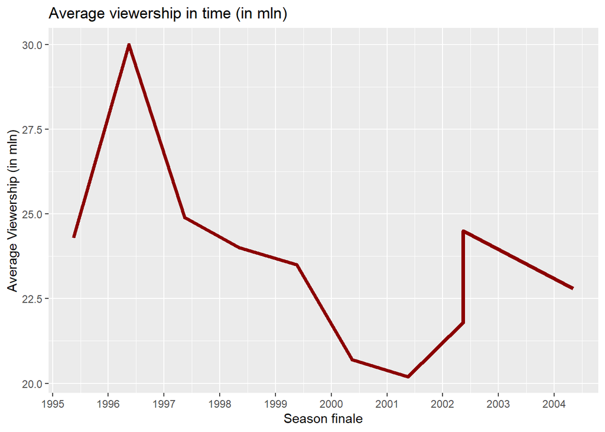

## Season to season changes in viewership

The following graph presents season to season changes in average viewership of episode during each season.

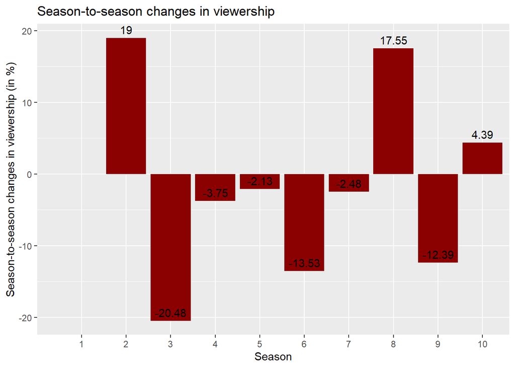

## Short description of changes in viewership

The change between the average viewership of episode between season 10 and 1 was **-1.5 mln**. The highest viewership was during season **2** and gained **30** mln views on average per episode. On the contrary, the season with lowest number of views was the **7th** one, and gained up to **20.2** mln views. The difference between both of those seasons is equal to **9.8** mln views.